# レポート(深層学習:Day3,Day4)

## ■Day3

DNNの目的は、

- 誤差を最小化するパラメータを発見すること
- 結果的には重みとバイアスの値が最適化される

### ■再帰型ニューラルネットワークについて

### Section1) 再帰型ニューラルネットワークの概念

#### 1-1. RNN全体像

RNN(Recurrent Neural Network)とは?

- 時系列データに対応可能な、ニューラルネットワーク
- 具体的な時系列データとしては？
  - 音声データ
  - 株価データ...etc

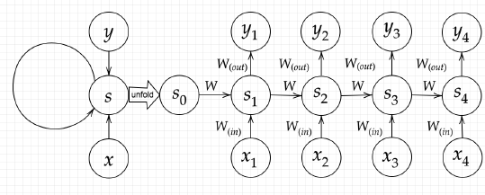

RNNでの3つの重み

- 入力から現在の中間層を定義する際にかけられる重み→ $ W_{(in)} $
- 中間層から出力を定義する際にかけられる重み→ $ W_{(out)} $
- 中間層から中間層を定義する際にかけられる重み→ $ W $

上記部分をコード化すると以下となる

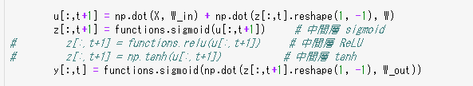

#### 1-2 BPTT

BPTT(Backpropagation Through Time)

- これまでの誤差逆伝播法を時間方向に展開したもの
- 長い時系列データを学習する場合に、計算リソースが増加する
- 勾配消失(不安定になる)ことがある

誤差逆伝播部のコードは以下

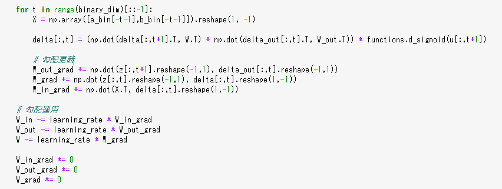

#### 考察

- weight_init_stdやlearning_rate, hidden_layer_sizeを変更してみる
  - weight_init_stdを小さく(=0.1)また大きく(=10)したら、lossは収束せず、発散した。
  - learning_rateを小さく(=0.01)したら発散したが、大きく(=1)したら、早く収束した。
  - hidden_layer_sizeを小さくしたら発散したが、大きく(=32)したら、収束した。

weight_init_std = 1  
learning_rate = 1  
hidden_layer_size = 16

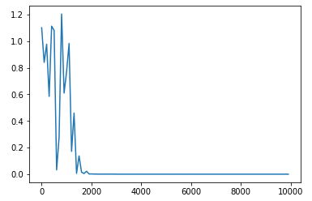

活性化関数=ReLUでの実行結果

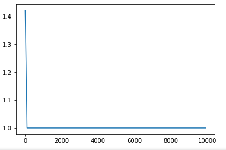

【実装演習結果】

https://lindbergh244.github.io/Report_StudyAI/3_1_simple_RNN_me.html

### Section2) LSTM (Long short-term memory)

- RNNの拡張として1995年に登場した時系列データに対するモデルの１つ
- RNNの持つ課題である勾配消失および勾配爆発(勾配クリッピング)を解決するために提案された
- RNNの中間層部、CEC(Constant Error Carousel)と3つのゲート(入力ゲート、忘却ゲート、出力ゲート)で構成される

#### 2-1 CEC

- 勾配消失および勾配爆発を解決するために、導入された
- 勾配を１にすることで解決できる
- 時間依存度に関係なく重みが一律になることで、学習特性がなくなる

#### 2-2 入力ゲートと出力ゲート

- 時系列データを学習する場合に、入力および出力で重み衝突(矛盾する重み更新を同時に受ける)する場合がある
- 重み衝突を回避するために、入力・出力にゲートを配置

#### 2-3 忘却ゲート

- CECは過去の情報がすべて溜めこむ構造
- 捨てることができない(入力系列パターンが変わったときに対応できない)
- 忘却ゲートにより、不要になったCECの情報を更新できるようにした

#### 2-4 覗き穴結合(Peephole Connection)

- CEC自身の値を使って、ゲート制御に影響を与えるようにしたもの

### Section3) GRU(Gated Reccurent Unit)

- LSTMの課題(パラメータが多く、計算に時間がかかる)を解決するために提案されたモデル
- 必ずしも上位互換ではない
- リセットゲート→ 過去の隠れ層の状態をどれだけ無視するかを決定する
- 更新ゲート→LSTMの忘却ゲートと入力ゲートを担う

### Section4) 双方向RNN

- 過去の情報だけでなく、未来の情報も加味することで、精度を向上させるためのモデル
- 順伝播の逆伝播の隠れ層の状態を連結して、最終的な隠れ状態ベクトルとする

### ■RNNでの自然言語処理

### Section5) Seq2seq(Sequence to sequence)

- Encoder-Decoderモデルの一種
- 使用用途としては、機械対話や機械翻訳に使用されている

#### 5-1 Encoder RNN

- テキストデータを単語等のトークンに区切って渡す構造で以下のステップで実施される
  1. Tokenize → 文章を単語等のトークンに分割。(英文の場合は、スペース、日本語の場合は、形態素解析等を使う)
  2. Embedding → トークンを分散表現ベクトルに変換
  3. Encoder RNN → ベクトル(vac)をRNNに入力していく
- 最後の隠れ層ベクトル(thought vector)をDecoder側の入力にする
- 結果的に、任意の文章を固定長ベクトルに変換することになる

#### 5-2 Decoder RNN

- Encoderから出力されたベクトルを入力として、以下のステップで実施される
  1. Decoder RNN → Encorder RNNの出力(thought vector)をRNNの隠れ層に入力する。  
     最初のRNNには区切り文字を使ってEmbeddingし、RNNに入力する。
  2. Sampling → RNNの出力からトークンを選択する
  3. Embedding → 2で選択されたトークンをベクトル化し、次のRNNに入力する
  4. Detokenize → 1-3を繰り返し、２で得られたトークンを文字列(文章)に変換する

#### 5-3 HRED(Hierarchical Recurrent Encoder Decoder)

- Seq2Seqの一問一答でしかできないのを改良したもの
- Seq2Seq + Context RNN
- Context RNNとは、Encoderのまとめた各文章の系列をまとめて、これまでの会話のコンテキスト全体を表すベクトルに変換する構造
- 課題として、会話の「流れ」のような多様性がない
  - 同じ答えを返しがち
  - 短い答えを選びがち

#### 5-4 VHRED(Variational Hierarchical Recurrent Encoder Decoder)

- HREDに、VAE(Variational Autoencoder)の潜在変数の概念を追加したもの
- 潜在変数zに確率分布$z～N(0,1)$を仮定している
- Context RNNの部分に確率的なノイズを与えて学習することで、HREDの課題を解決する

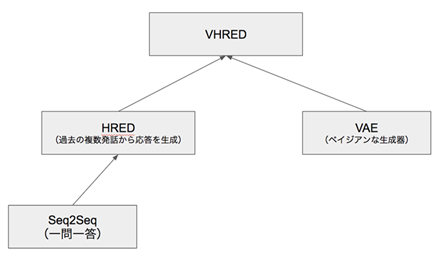

### Section6) Word2vec

- 単語を固定長ベクトルで表現する方法
- 単語同士の意味の近さや、意味を足したり引いたりできるようになる
- カウントベースと推論ベース
  - カウントベース× → 語彙数 x 語彙数の重み行列
  - 推論ベース ○ → 語彙数 x 任意の単語ベクトル次元の重み行列
- CBOWモデルとskip-gramモデル
  - CBOW → コンテキスト(周囲の単語)からターゲット(中央の単語)を推測する
  - skip-gram → ターゲット(中央の単語)からコンテキスト(周囲の単語)を推測する

### Section7) Attention Mechanism

- seq2seqでは、長い文章への対応が難しい  
  → 固定次元ベクトルの中に入力しなければいけない
- Attention Mechanism → 入力と出力のどの単語が関連しているのかを学習する仕組み
- Attentionを用いることで、単語と単語の関連性を視覚的に確認できるようになる

## ■Day4

### Section1) TensorFlowの実装演習

#### tensorflowを使ったコーディングの特徴

- Sessionを起動して、runしないと実行されない
- PlaceHolderはデータの箱のようなもので、データの型を定義する必要がある
- Variableを使う場合は、初期化する必要がある
- Variable変数を値を代入する場合は、assignを使う

#### tensorflowを使ったDNN記述構造

1. ハイパーパラメータの設定
2. 変数(重み、バイアスなど)の設定
3. ネットワークの設定
4. 損失関数の設定
5. トレイナー(学習をする為のクラス)の設定
6. 精度評価関数設定
7. 変数初期化、セッションの起動
8. 学習の実行
9. 結果の表示(グラフ化など)
10. ネットワークの保存

【実装演習結果】

https://lindbergh244.github.io/Report_StudyAI/4_1_tensorflow_me.html

#### Kerasを使ったコーディングの特徴

- Tensorflowのラッパー
- 初心者に使いやすい
- functionnalとSequencialがある
  - functional → 複雑なモデル(複数の入出力を持ったモデルなど)を作る場合に使用する
  - sequencial → 簡単なモデルの場合、実装演習ではこちらを使用
- Kerasを使う場合は、ドキュメントを参照する  
  https://keras.io/ja/

【実装演習結果】

https://lindbergh244.github.io/Report_StudyAI/4_3_keras_codes_me.html

### Section2) 強化学習

長期的に報酬を最大化できるように環境の中で選択できるエージェントを作ることを目標とする機械学習の一分野  
→行動の結果として与えられる利益(報酬)をもとに、行動を決定する原理を改善していく仕組み

#### 2-3. 探索と利用のトレードオフ

- 利用と探索のバランスをとることが重要!!
- 利用→過去のデータからベストな行動をとる
- 探索→これまでとは違う未来の行動をとる

#### 2-4. 強化学習のイメージ

1. 方策関数によって行動を決定
2. その行動によって発生した状態より報酬を決定
3. その報酬を最大化できるように学習する

#### 2-5. 強化学習の差分

- 教師あり学習 → 「入力と出力の関係」を学習する(回帰、分類)
- 教師なし学習 → 「データの構造」を学習する(分類)、「クラスタリング」、「次元削減」
- 強化学習 → 「価値を最大化するような行動」を学習する

強化学習が注目集めるきっかけ

- 計算速度の向上
- 関数近似法とQ学習

#### 2-6. 行動価値関数

価値関数としては2つに分類

- 状態価値関数→ 状態sにいることの価値 $ \hspace{5mm} V^{\pi}(s) $
- 行動価値関数→ 状態sにいて、行動をaを取る価値 $ \hspace{5mm} Q^{\pi}(s, a) $

#### 2-7. 方策関数

状態sを入力として、行動aを出力(選択)する関数

- 一意な行動を出力する決定的方策 $ \hspace{10mm} a = \pi(s) $
- 行動の確率分布を出力する確率的方策 $ \hspace{10mm} \mathbb{P} (a) = \pi(a|s) $

#### 2-8. 方策勾配法

$ \theta $をパラメータとする方策$\pi_{\theta}$に対して、期待収益$J(\theta)$を確率的勾配法で最大化する方法  
$ \hspace{10mm} \theta^{t+1} = \theta^{(t+1)} + \alpha J(\theta) $  
$ \hspace{10mm} where \hspace{5mm} J(\theta) = V^{\pi \theta} ( s_t) $  
$ \hspace{36mm} = \sum_{a} \pi_{\theta} ( a | s) Q^{\pi \theta} (s, a) $

報酬の定義の方法としては、

- 平均報酬 → 行動をとったときに生まれる価値の全部の平均を取ったもの
- 割引報酬 → 遠い将来に得られる報酬ほど割引いて評価する

それぞれの場合では、行動価値関数$Q(s,a)$と状態sに関する関数$d(s)$ の定義の仕方が異なる 結果として、以下の方策勾配定理が成立する  
$ \hspace{10mm} \nabla_{\theta} J(\theta) = \mathbb{E}_{\pi_{\theta}} [ \nabla_\theta log \pi_\theta(a|s) q^\pi(s, a))] $